# Programming Homework

Statistics 98

Alireza Darvishi

2020-04-23 11:18:07

[figure not shown]

# programming Homework: US Air pollution

با استفاده از داده های آلودگی هوای آمریکا در سال ۲۰۱۸ به سوالات زیر پاسخ دهید. برای تصویرسازی از پکیج ggplot2 استفاده کنید.

ابتدا فایل دیتای مورد بررسی را لود می کنیم و سپس پکیج های مورد استفاده را لود می کنیم.

```r
data<-read.csv(file = "./daily_aqi_by_county_2018.csv")
library(dplyr)
```

```r
library(ggplot2)
library(usmap)
library(tidyr)
```

۱. آلوده ترین منطقه، چه منطقه ای بوده است؟ نمودار ستونی ۲۰ منطقه با بیشترین آلودگی را رسم کنید. این کار را برای ایالت ها نیز تکرار کنید.

برای کشیدن نمودار ستونی ۲۰ آلودگی بیشینه کاری مشابه با قبل انجام می دهیم اما این بار داده ها را با آلودگی ترتیب می دهیم و نمودار میله ای را رسم می کنیم.

برای رسم نمودار میله ای از پکیج ggplot2 استفاده می کنیم.

برای نمودار مشابه برای ایالت ها فقط روی ایالت ها گروه بندی انجام می دهیم.

```r
# data %>% group_by(State.Name,county.Name) %>% summarise(AQI=max(AQI))
data %>% group_by(State.Name,county.Name) %>% summarise(AQI=mean(AQI)) %>% .[which.max(.$AQI),] %>% .[2] %>% print(.,max.levels=0)
```

```
## # A tibble: 1 x 1
##   county.Name
##   <fct>
## 1 Hawaii
```

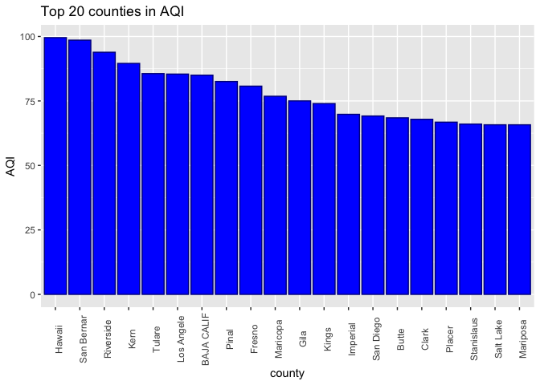

```r
data %>% group_by(State.Name,county.Name) %>% summarise(AQI=mean(AQI)) %>% .[order(.$AQI,decreasing = TRUE),] %>% .[1:20,] %>% ggplot(., aes(x=reorder((function (x) substr(x,1,10))(county.Name),-AQI), y=AQI)) +geom_bar(stat="identity",color="darkblue",fill="blue")+labs(x="county",title = "Top 20 counties in AQI")+theme(axis.text.x = element_text(angle=90))
```

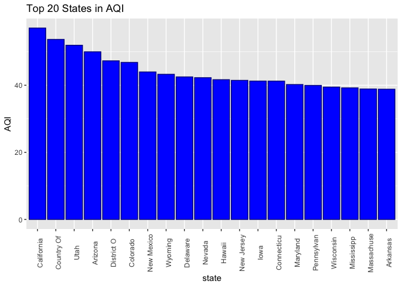

```r
data %>% group_by(State.Name) %>% summarise(AQI=mean(AQI)) %>% .[order(.$AQI,decreasing = TRUE),] %>% .[1:20,] %>% ggplot(., aes(x=reorder((function (x) substr(x,1,10))(State.Name),-AQI), y=AQI)) +geom_bar(stat="identity",color="darkblue",fill="blue")+labs(x="state",title = "Top 20 States in AQI")+theme(axis.text.x = element_text(angle=90))
```

۲. نمودار جعبه ای آلودگی هوا را بر حسب درجه کیفی آلودگی هوا(Category) رسم کنید.

با استفاده از پیکیج ggplot داده ها را به صورت نمودارهای جعبه نمایش می دهیم.

داده ها را بر اساس نوع آلودگی دسته بندی میکنیم و بر اساس آلودگی مرتب می کنیم.

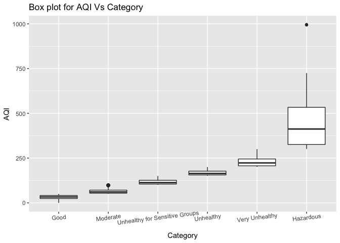

```r
data %>% ggplot(., aes(group =Category,x=reorder(Category,AQI), y=AQI)) + geom_boxplot() +labs(x="Category",title = "Box plot for AQI Vs Category") + theme(axis.text.x = element_text(angle=7))
```

۳. نمودار خطی میانگین آلودگی هوای امریکا را بر حسب زمان رسم کنید.

میانگین آلودگی بر حسب زمان را بدست می آوریم و نمودار آلودگی بر حسب زمان را رسم می کنیم.

برای بدست آوردن میانگین آلودگی برحسب زمان از group_by روی Date استفاده می کنیم.

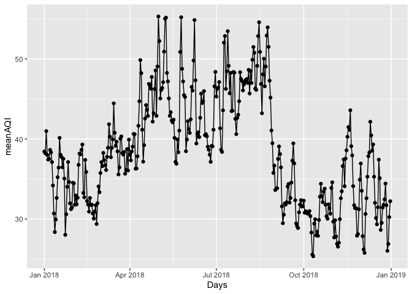

```r
data %>% group_by(Date) %>% summarise(.,meanAQI=mean(AQI)) %>% mutate(.,Days=as.Date(Date)) %>% ggplot(.,aes(x=Days,y=meanAQI))+geom_point()+geom_line()
```

۴. نمودار ستونی مهم ترین آلاینده های هوای واشنگتن را رسم کنید و بگویید که مهم ترین آلاینده هوای واشنگتن چه آلاینده ای است

ابتدا داده های واشنگتن را جدا می کنیم و سپس از group_by روی پارامتر آلوده کننده استفاده میکنیم و نمودار خواسته شده را با ggplot رسم می کنیم.  
همانطور که از نمودار دیده می شود مهمترین دلیل آلودگی ozon است.

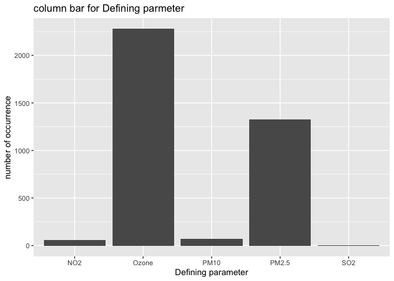

```r
#data %>% filter(.,county.Name=="Washington") %>% group_by(Defining.Parameter) %>% summarise(days=n()) %>% View()
data %>% filter(.,county.Name=="Washington") %>% group_by(Defining.Parameter) %>% ggplot(.,aes(x=Defining.Parameter))+geom_bar()+labs(y="number of occurrence",x="Defining parameter",title="column bar for Defining parmeter")
```

۵. می خواهیم بازه اطمینانی نود و پنج درصدی برای میانگین آلودگی هوای هر منطقه به دست بیاوریم. یک dataframe جدید بسازید که در آن مقابل اسم هر منطقه، ابتدا و انتهای بازه اطمینان در دو ستون مختلف نوشته شده باشد.

برای بدست آوردن بازه ی اطمینانی برای آلودگی هوا اول دیتا را روی منطقه دسته بندی می کنیم و سپس میانگین و بازه ی اطمینان را با استفاده از یک تست آماری بدست می آوریم. فرض می کنیم میانگین از تابع توزیع t پیروی می کند.

```r
data %>% group_by(county.Name) %>% summarise(mean=mean(AQI),lowerbound=t.test(AQI)$conf.int[1],upperbound=t.test(AQI)$conf.int[2])
```

```
## # A tibble: 815 x 4
##    county.Name  mean lowerbound upperbound
##    <fct>       <dbl>      <dbl>      <dbl>
##  1 Ada          44.1       42.1       46.1
##  2 Adair        39.6       38.0       41.2
##  3 Adams        35.4       34.4       36.4
##  4 Adjuntas     15.3       13.2       17.5
##  5 Aiken        38.4       36.8       40.1
##  6 Alachua      34.8       33.6       35.9
##  7 Alameda      56.4       53.6       59.3
##  8 Alamosa      21.1       19.5       22.8
##  9 Albany       45.6       44.5       46.8
## 10 Albemarle    36.1       34.5       37.6
## # … with 805 more rows
```

۶. با طراحی آزمون فرض، این ادعا را بررسی کنید:  
«در زمستان، هوا از تابستان آلوده تر است.»

```r
summer_data <- data %>% filter(as.Date(Date)>=as.Date("2018-07-01") & as.Date(Date)<as.Date("2018-10-01")) %>% group_by(county.Name) %>% summarise("mean_AQI_in_summer"=mean(AQI))
winter_data <- data %>% filter(as.Date(Date)>=as.Date("2018-01-01") & as.Date(Date)<as.Date("2019-04-01")) %>% group_by(county.Name) %>% summarise("mean_AQI_in_winter"=mean(AQI))
merge(winter_data,summer_data,"county.Name") %>% with(.,t.test(mean_AQI_in_winter,mean_AQI_in_summer,paired = TRUE,alternative = "greater"))
```

```
##
##  Paired t-test
##
## data:  mean_AQI_in_winter and mean_AQI_in_summer
## t = -13.668, df = 810, p-value = 1
## alternative hypothesis: true difference in means is greater than 0
## 95 percent confidence interval:
##  -4.231293       Inf
## sample estimates:
## mean of the differences
##               -3.776313
```

```r
t.test(winter_data$mean_AQI_in_winter,summer_data$mean_AQI_in_summer,alternative = "greater")
```

```
##
##  Welch Two Sample t-test
##
## data:  winter_data$mean_AQI_in_winter and summer_data$mean_AQI_in_summer
## t = -5.4646, df = 1486.9, p-value = 1
## alternative hypothesis: true difference in means is greater than 0
## 95 percent confidence interval:
##  -5.02616      Inf
## sample estimates:
## mean of x mean of y
##  38.34705  42.20980
```

۷. با طراحی آزمون فرض، این ادعا را بررسی کنید:  
«آلودگی هوای زمستان و تابستان با هم تفاوت دارد.»  
نتیجه این آزمون را با بخش قبل مقایسه کنید.

```r
merge(winter_data,summer_data,"county.Name") %>% with(.,t.test(mean_AQI_in_winter,mean_AQI_in_summer,paired = TRUE))
```

```
##
##  Paired t-test
##
## data:  mean_AQI_in_winter and mean_AQI_in_summer
## t = -13.668, df = 810, p-value < 2.2e-16
## alternative hypothesis: true difference in means is not equal to 0
## 95 percent confidence interval:
##  -4.318645 -3.233981
## sample estimates:
## mean of the differences
##               -3.776313
```

```r
t.test(winter_data$mean_AQI_in_winter,summer_data$mean_AQI_in_summer)
```

```
##
##  Welch Two Sample t-test
##
## data:  winter_data$mean_AQI_in_winter and summer_data$mean_AQI_in_summer
## t = -5.4646, df = 1486.9, p-value = 5.431e-08
## alternative hypothesis: true difference in means is not equal to 0
## 95 percent confidence interval:
##  -5.249303 -2.476197
## sample estimates:
## mean of x mean of y
##  38.34705  42.20980
```

۸. با طراحی آزمون فرض، این ادعا را بررسی کنید:  
«آلودگی هوای تگزاس و میشیگان، تفاوت معناداری با هم ندارد.»

در هر روز، آلودگی میانگین هوا در هر یک از دو ایالت را بدست می آوریم.  
سپس در هر روز خاص، اختلاف این میانگین در میشیگان و تگزاس را به عنوان یک متغیر در نظر می گیریم و با آزمون فرض بررسی می کنیم آیا این میانگین صفر است. به این شکل که فرض صفر این است که اختلاف آلودگی در هر روز صفر است و فرض مخالف این است که این دو میانگین متفاوت هستند.  
نتیجه این است که میانگین آلودگی در هر روز متفاوت نیست و فرض صفر رد نمی شود.

```r
merge( data %>% filter(State.Name=="Michigan") %>% group_by(Date) %>% summarise(mean_AQI_in_Michigans=mean(AQI)) , data %>% filter(State.Name=="Texas") %>% group_by(Date) %>% summarise(mean_AQI_in_Texas=mean(AQI)) ,"Date") %>% with(.,t.test(mean_AQI_in_Michigans,mean_AQI_in_Texas,paired = TRUE))
```

```
##
##  Paired t-test
##
## data:  mean_AQI_in_Michigans and mean_AQI_in_Texas
## t = 0.37426, df = 364, p-value = 0.7084
## alternative hypothesis: true difference in means is not equal to 0
## 95 percent confidence interval:
##  -1.114053  1.637780
## sample estimates:
## mean of the differences
##               0.2618634
```

۹. با استفاده از تحلیل واریانس و محاسبه آماره ی F و p-value فرضیه زیر را بررسی کنید.  
«آلودگی هوای سه ایالت کالیفرنیا، نیویورک و آلاباما تفاوت معناداری ندارد.»

ابتدا با فیلتر روی نام ایالت داده های ایالت های مورد نظر را جدا می کنیم. سپس میانگین آلودگی در هرروز برای آن ایالت را بدست می آوریم. حال از آزمون F استفاده می کنیم و p-value ای که بدست می آوریم بسیار کوچک است.  
این یعنی فرض صفر که یکسان بودن میانگین آلودگی است رد می شود.  
و می توانیم بگوییم میانگین آلودگی ها یکسان نیست.

```r
data %>% filter(State.Name=="California" | State.Name=="New York" | State.Name=="Alabama") %>% group_by(.,State.Name,Date) %>% summarise(mean_AQI=mean(AQI)) %>% aov(mean_AQI~State.Name,data=.) %>% summary(.)
```

```
##               Df Sum Sq Mean Sq F value Pr(>F)
## State.Name     2 111850   55925   283.7 <2e-16 ***
## Residuals   1092 215283     197
## ---
## Signif. codes:  0 '***' 0.001 '**' 0.01 '*' 0.05 '.' 0.1 ' ' 1
```

۱۰. سه آماره به همراه نمودار جالب استخراج کنید.

در نمودار اول، تعداد سایت های ثبت داده برحسب تعداد بارهایی که این اتفاق افتاده رسم شده که نزولی است!  
در نمودار دوم درصد مناطق برحسب کتگوری و برحسب زمان رسم شده اند.  
در نمودار سوم و چهارم، مهمترین آلاینده در هر منطقه و ایالت بدست آمده و روی نقشه ی آمریکا گذاشته شده است!  
دلیل عدم وجود دیتای کافی در نقشه ی اول، عدم وجود داده برای تمام مناطق است.

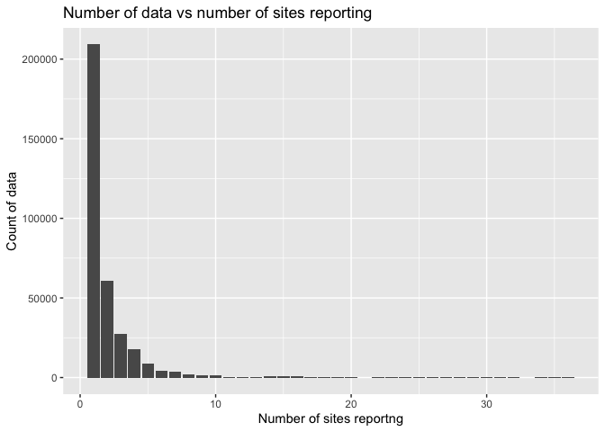

```r
data  %>% ggplot(aes(group=Number.of.Sites.Reporting,x=Number.of.Sites.Reporting))+geom_bar()+labs(x="Number of sites reportng", title = "Number of data vs number of sites reporting",y="Count of data")
```

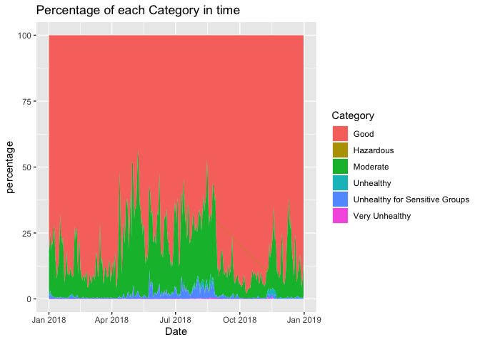

```r
data %>% group_by(Date,Category) %>% summarise(n=n()) %>% mutate(percentage=100*n/sum(n)) %>% ggplot(aes(fill=Category,x=as.Date(Date),y=percentage))+geom_area()+labs(x="Date",title = "Percentage of each Category in time")
```

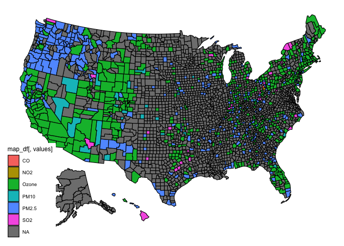

```r
data %>% filter(State.Name!="Alaska" & State.Name!="Illinois" & State.Name!="Louisiana" &State.Name!="Maryland" & State.Name!="Minnesota" & State.Name!="Missouri"&State.Name!="Virginia") %>% group_by(State.Name,county.Name,Defining.Parameter) %>% summarise(n=n()) %>%  mutate(most_important=Defining.Parameter[which.max(n)]) %>% summarise(most_important=most_important[1]) %>% ungroup() %>% rowwise() %>% mutate(fips=fips(State.Name)) %>% drop_na() %>% rowwise() %>% mutate(fips=fips(State.Name,county = county.Name)) %>% plot_usmap(data=.,values="most_important")
```

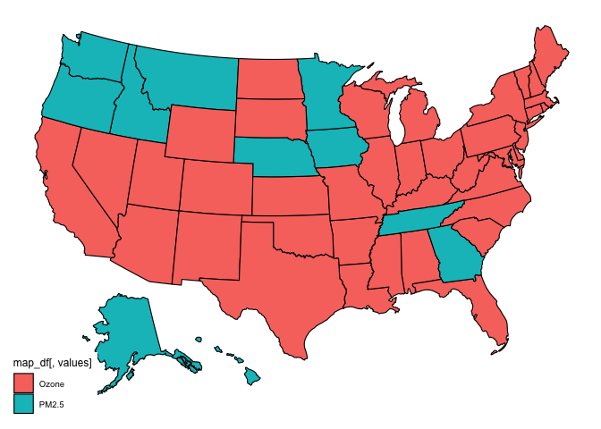

```r
data  %>% group_by(State.Name,Defining.Parameter) %>% summarise(n=n()) %>%  mutate(most_important=Defining.Parameter[which.max(n)]) %>% summarise(most_important=most_important[1]) %>% ungroup() %>% rowwise() %>% mutate(fips=fips(State.Name)) %>% drop_na() %>% plot_usmap(data=.,values="most_important")
```